# Simulation plot

Yichen

6/2/2020

## Simulation 1

### Parameters

- **Parameter**
  - 3 legacy trials and 1 future trial (n = 600 each)
  - For each trial:
    - 1 causal feature x (not observed) with coefficient
    - Outcome $y = \beta x + \epsilon$, $x$ not observed in data
    - $Q$ candidate correlated features
    - $q$ truly correlated features with correlation $\rho$ (randomly selected)
    - 15 noise features
- **Outcomes**
  - Oracle $R^2$ (orange solid line)
  - Generalized $R^2$ (blue solid line)
  - Estimated generalized $R^2$ with 10-fold cross-validation (blue dashed line)
  - Estimated generalized $R^2$ with leave-one-study-out cross-validation (blue dotted line)
- **Detailed explanation**
  - Oracle $R^2$ is calculated analytically
    - assume we do not observe the causal feature x but we know $\beta$, $\rho$ and which features are correlated over the 3 legacy trials
    - suppose we are given a new (not previously seen) observation from one of the 3 legacy trials and we **know** which trial the new observation comes from
    - we then build the best simple linear regression model for predicting the y value and the oracle $R^2$ is derived from this model
  - Generalized $R^2$ is calculated empirically using the model built on legacy data to predict observations from future trial
    $$R^2 = 1 - \frac{MSPE}{MSE} = 1 - \frac{\frac{1}{n}\sum(y - \hat y)^2}{\frac{1}{n}\sum(y - \overline y)^2}$$
  - Estimated generalized $R^2$ from 10-fold cross-validation is obtained as follows
    - Combine the data from all 3 legacy trials
    - Train the model on 9 folds of the data and predict on the left-over 1 fold
    - Repeat the process for each of the 10 fold and average the 10 $R^2$
  - Estimated generalized $R^2$ from leave-one-out cross-validation is obtained as follows
    - Train the model on 2 of the legacy trials and predict on the other trial to obtain MSPE.
    - Repeat the process for each of the 3 legacy trials and average the 3 $R^2$

### Result 1a

- **Hypothesis: As number of truly correlated features $q$ increases, the correlated features picked up by the legacy model are more likely to overlap with correlated features in the future trials, which leads to smaller difference between generalized $R^2$ and estimated generalized $\hat R^2$**
- Fix Q, as q increase, generalized $R^2$ and two $\hat R^2$ all increase towards the oracle $R^2$. The difference between generalized $R^2$ and $\hat R^2$ decreases as we have a larger proportion of candidate correlated features among candidate correlated features.
- While $\hat R^2$ from 10-fold cv largely overestimates the generalized $R^2$, $\hat R^2$ from loo cv corrects this gap and does a better job at estimating the generalized $R^2$.
- Lasso regression performs similarly compared to simple linear regression when we have small number of correlated features

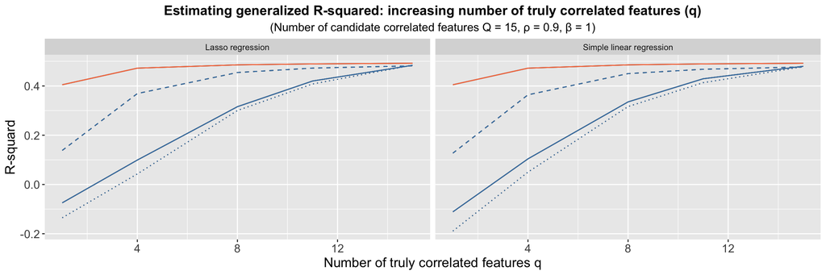

- Lasso regression outperforms simple linear regression when we have large number of correlated features

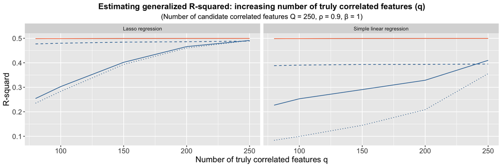

- With larger coefficient $\beta$, we will also have larger oracle $R^2$
- We observe larger difference between generalized $R^2$ and $\hat R^2$ from 10-fold cv.
- $\hat R^2$ from loo cv still does a good job estimating generalized $R^2$.

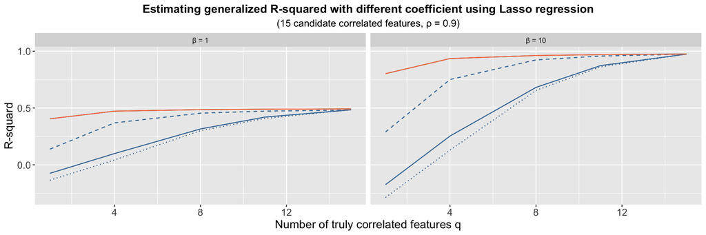

- With larger correlation $\rho$, we will also have larger oracle $R^2$.
- While the $\hat R^2$ from 10-fold cv largely overestimate the generalized $R^2$, $\hat R^2$ from loo cv approximates generalized $R^2$ well, only mildly influenced by correlation change.

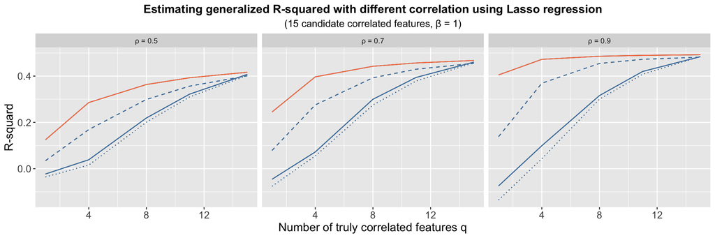

### Result 1b

- **Hypothesis: As candidate correlated features $Q$ increases, the correlated features in the legacy model are less likely to overlap with correlated features in the future trials. This leads to larger difference in generalized $R^2$ and $\hat R^2$.**
- Fix number of truly correlated feautures $q = 15$, as Q increase, both $R^2$ and $\hat R^2$ from 10-fold cv or loo cv decrease. But generalized $\hat R^2$ decreases much faster. We observe a larger difference between $R^2$ and $\hat R^2$ as the proportion of truly correlated features among candidate correlated features decreases.
- Similarly, $\hat R^2$ from 10-fold cv overestimates the generalized $R^2$, $\hat R^2$ from loo cv performs better at estimating the generalized $R^2$.
- Lasso regression performs similarly compared to simple linear regression when we only have 15 truly correlated features

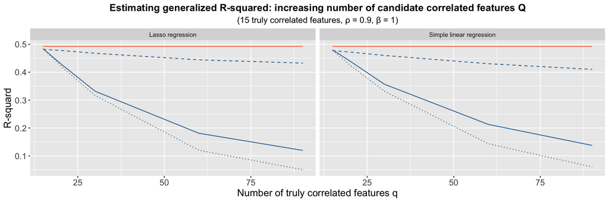

## Simulation 2

- Updated simulation
  - Distinct correlated features in each trial (no overlap)
  - An additional oracle $R^2$ is calculated analytically (green solid line)
    - assume we do not observe the causal feature $x$ but we know $\beta$, $\rho$ and which features are correlated over the 3 legacy trials.
    - the correlated features in each legacy trial will be distinct and there’s no overlap.
    - suppose we are given a new (not previously seen) observation from one of the 3 legacy trials but we **do not know** which trial the new observation comes from
    - assume there is an equal probability that the new observation comes from each of the 3 trials
    - we then build the best simple linear regression model for predicting the y value , and the oracle $R^2$ is derived from this model.
- Lasso regression returns higher generalized $R^2$ and $\hat R^2$ overall. $\hat R^2$ from loo cv approximates generalized $R^2$ slightly better compared to that of simple linear regression.

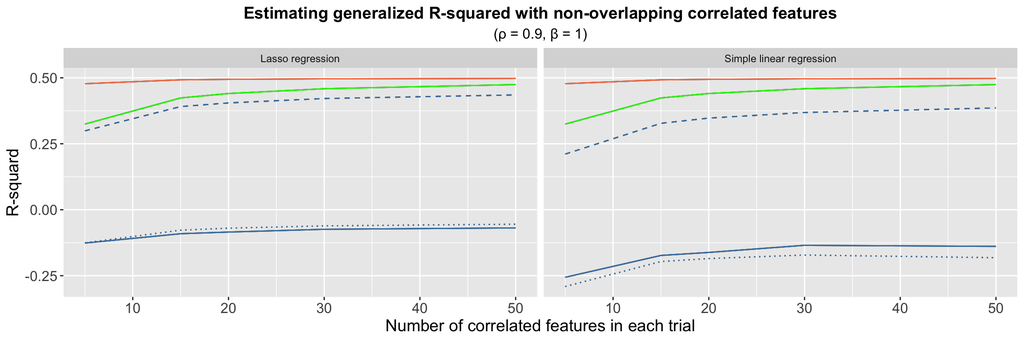

- With stronger correlation $\rho$, we observe larger generalized $R^2$ and $\hat R^2$. Oracle $R^2$ based on both assumptions increase with increasing number of truly correlated features and coefficient.
- Overall, lasso regression returns higher generalized $R^2$ and $\hat R^2$ compared to simple linear regression.

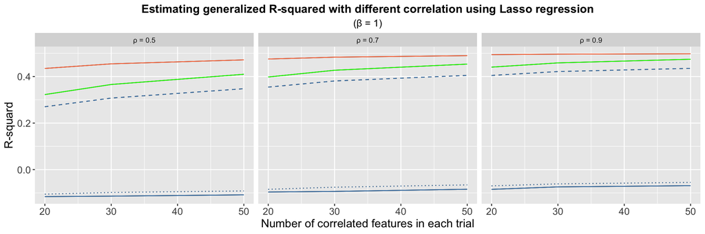

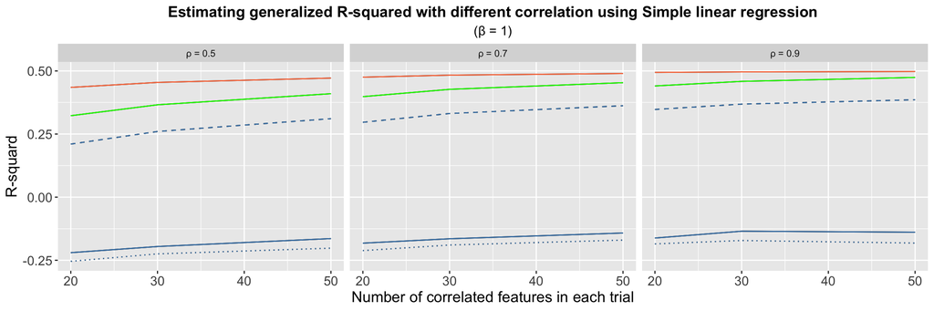

## Calculation

### Observed causal feature

Oracle $R^2$ when we get to observe the causal feature $X$ is calculated as follows

$
$$\begin{aligned}
y = \beta X + \epsilon, X \sim N(0, 1), \epsilon \sim N(0, 1) \\
y|X = x \sim N(\beta x, 1)\\
var(Y)
&= var(\beta X + \epsilon) \\
&= \beta^2 var(X) + var(\epsilon) + 2Cov(X, \epsilon) \\
&= \beta^2 + 1 \\
\\
cov(y, X)
&= E[yX] - E[y]E[X] \\
&= E[\beta X^2 + X\epsilon] - 0 \\
&= \beta E[X^2] + E[X]E[\epsilon] \\
&= \beta \\
\\
R^2 = 1 - \frac{var(y|x)}{var(y)} = 1 - \frac{var(\epsilon)}{\beta ^ 2var(x) + var(\epsilon)} = 1 - \frac{1}{\beta^2+1}\\
\end{aligned}$$

$

### Causal feature not observed and trial number available

**Scenario 1**: We only have 1 legacy trial with 1 correlated feature $\tilde{X}$ such that $\tilde{X}|X = x = \rho x + \sqrt{1-\rho^2} Z$

Oracle $R^2$ is calculated as follows:

$\begin{aligned} y = \tilde{\beta} \tilde{X} + \tilde{\epsilon}, \tilde{X} \sim N(0, 1) \\ cov(\tilde{X}, X) = \rho Var(X) Var(\tilde{X}) = \rho \\ \\ cov(y, \tilde{X}) &= E[y\tilde{X}] - E[y]E[\tilde{X}] \\ &= E[(\beta X + \epsilon) \tilde{X}] - 0 \\ &= E[(\beta X \tilde{X}] + E[\epsilon \tilde{X}] \\ &= E[\beta X \tilde{X}] + E[\epsilon] E[\tilde{X}]\\ &= \beta E[X \tilde{X}]\\ &= \beta E[X E(\tilde{X}|X)]\\ &= \beta E[X \rho X]\\ &= \beta \rho\\ \end{aligned}$

$\begin{aligned} R^2 &= 1 - \frac{Var(y|\tilde{X})}{Var(y)} \\ &= 1- \frac{\beta^2 + 1 - \beta^2 \rho ^2}{\beta^2 + 1} \\ \end{aligned}$

**Scenario 2**: We only have 1 legacy trial with 2 correlated feature $\tilde{X_1}, \tilde{X_2}$ both with correlation $\rho$ such that $\tilde{X_1}|X = x = \rho x + \sqrt{1-\rho^2} Z_1$, $\tilde{X_2}|X = x = \rho x + \sqrt{1-\rho^2} Z_2$

Oracle $R^2$ is calculated as follows:

$\begin{aligned} cov(\tilde{X_1}, \tilde{X_2}) &= E[\tilde{X_1} \tilde{X_2}] - E[\tilde{X_1}]E[\tilde{X_2}] \\ &= E[\tilde{X_1} E[\tilde{X_2}| \tilde{X_1}] - 0 \\ &= E[\tilde{X_1} E[\rho x + \sqrt{1-\rho^2} Z_2| \tilde{X_1}]] \\ &= E[\tilde{X_1} E[\rho x | \tilde{X_1}]] \\ &= E[\tilde{X_1} \rho E[x | \tilde{X_1}]] \\ &= E[\tilde{X_1} \rho^2] \\ &= \rho ^ 2\\ \end{aligned}$

$\begin{aligned} \begin{bmatrix} y\\ \tilde{X}_1\\ \tilde{X}_2\\ \end{bmatrix} \sim N \left( \begin{bmatrix} 0\\ 0\\ 0 \end{bmatrix}, \begin{bmatrix} \beta^2 + 1 & \beta\rho & \beta\rho\\ \beta\rho & 1 & \rho^2\\ \beta\rho & \rho^2 & 1 \end{bmatrix} \right) \end{aligned}$

### Causal feature not observed and trial unknown

**Scenario 1**: We have 2 legacy trials: legacy trial 1 has correlated feature $\tilde{X_1}$ and legacy trial 2 has correlated feature $\tilde{X_2}$ both with correlation $\rho$ such that

$$\begin{aligned}
\tilde{X_1}|X = x, t = 1 = \rho x + \sqrt{1-\rho^2} Z_1 \\
\tilde{X_2}|X = x, t = 2 = \rho x + \sqrt{1-\rho^2} Z_2 \\
\end{aligned}$$

The covariance matrix between $y, \tilde{X_1}, \tilde{X_2}$ is presented and oracle $R^2$ is calculated as follows.

$\begin{aligned} cov(\tilde{X_1}, \tilde{X_2}) &= E[\tilde{X_1} \tilde{X_2}] - E[\tilde{X_1}] E[\tilde{X_2}]\\ &= E[\tilde{X_1} \tilde{X_2}|t = 1] Pr(t = 1) + E[\tilde{X_1} \tilde{X_2}|t = 2] Pr(t = 2)\\ &= \frac{1}{2} * 0 * + \frac{1}{2} * 0\\ &= 0 \\ cov(X, \tilde{X_1}) &= E[X\tilde{X_1}] - E[X]E[\tilde{X_1}] \\ &= E[X\tilde{X_1}|t = 1] Pr(t = 1) + E[X\tilde{X_1}|t = 2] Pr(t = 2)\\ &= \frac{1}{2}E[X E(\tilde{X_1}|X)]+ \frac{1}{2} * 0\\ &= \frac{1}{2}E[X E(\rho X + \sqrt{1-\rho^2} Z_{1}|X)] \\ &= \frac{\rho}{2}\\ \\ cov(Y, \tilde{X_1}) &= E[Y\tilde{X_1}] - E[Y]E[\tilde{X_1}] \\ &= E[\tilde{X_1} E[Y|\tilde{X_1}]] \\ &= E[\tilde{X_1} E[\beta x + \epsilon|\tilde{X_1}]]\\ &= \beta E[\tilde{X_1} E[X|\tilde{X_1}]]\\ &= \frac{\beta \rho}{2} \end{aligned}$

$\begin{aligned} \begin{bmatrix} y\\ \tilde{X}_1\\ \tilde{X}_2\\ \end{bmatrix} \sim N \left( \begin{bmatrix} 0\\ 0\\ 0 \end{bmatrix}, \begin{bmatrix} \beta^2 + 1 & \frac{\beta\rho}{2} & \frac{\beta\rho}{2}\\ \frac{\beta\rho}{2} & 1 & 0\\ \frac{\beta\rho}{2} & 0 & 1 \end{bmatrix} \right) \\ \end{aligned}$

**Scenario 2**: We have 3 legacy trials: legacy trial 1 has correlated feature $\tilde{X_1}, \tilde{X_2}$, and legacy trial 2 has correlated feature $\tilde{X_3}, \tilde{X_4}$ and legacy trial 3 has correlated features $\tilde{X_5}, \tilde{X_6}$ such that

$$\begin{aligned}
\tilde{X_1}|X = x, t = 1 = \rho x + \sqrt{1-\rho^2} Z_1 \\
\tilde{X_2}|X = x, t = 1 = \rho x + \sqrt{1-\rho^2} Z_2 \\
\tilde{X_3}|X = x, t = 2 = \rho x + \sqrt{1-\rho^2} Z_3 \\
\tilde{X_4}|X = x, t = 2 = \rho x + \sqrt{1-\rho^2} Z_4 \\
\tilde{X_5}|X = x, t = 3 = \rho x + \sqrt{1-\rho^2} Z_5 \\
\tilde{X_6}|X = x, t = 3 = \rho x + \sqrt{1-\rho^2} Z_6 \\
\\
\end{aligned}$$

$\begin{aligned} cov(\tilde{X_1}, \tilde{X_3}) &= E[\tilde{X_1} \tilde{X_3}] - E[\tilde{X_1}] E[\tilde{X_3}]\\ &= E[\tilde{X_1} \tilde{X_3}|t = 1] Pr(t = 1) + E[\tilde{X_1} \tilde{X_3}|t = 2] Pr(t = 2) + E[\tilde{X_1} \tilde{X_3}|t = 3] Pr(t = 3)\\ & = 0\\ \\ cov(X, \tilde{X_1}) &= E[X\tilde{X_1}] - E[X]E[\tilde{X_1}]\\ &= E[\tilde{X_1} \tilde{X}|t = 1] Pr(t = 1) + E[\tilde{X_1} \tilde{X}|t = 2] Pr(t = 2) + E[\tilde{X_1} \tilde{X}|t = 3] Pr(t = 3)\\ &= \frac{1}{3}E[X E(\tilde{X_1}|X)] + \frac{2}{3} * 0\\ &= \frac{1}{3}E[X E(\rho X + \sqrt{1-\rho^2} Z_{1}|X)]\\ &= \frac{\rho}{3}\\ \\ cov(\tilde{X_1}, \tilde{X_2}) &= E[\tilde{X_1} \tilde{X_2}] - E[\tilde{X_1}]E[\tilde{X_2}] \\ &= E[\tilde{X_1} \tilde{X_2}|t = 1] Pr(t = 1) + E[\tilde{X_1} \tilde{X_2}|t = 2] Pr(t = 2) + E[\tilde{X_1} \tilde{X_2}|t = 3] Pr(t = 3)\\ &= \frac{1}{3} E[\tilde{X_1} \tilde{X_2}|t = 1] + \frac{2}{3} * 0\\ &= \frac{\rho ^ 2}{3}\\ \\ cov(Y, \tilde{X_1}) &= E[Y\tilde{X_1}] - E[Y]E[\tilde{X_1}] \\ &= E[\tilde{X_1} E[Y|\tilde{X_1}]] \\ &= E[\tilde{X_1} E[\beta x + \epsilon|\tilde{X_1}]]\\ &= \beta E[\tilde{X_1} E[X|\tilde{X_1}]]\\ &= \frac{\beta \rho}{3}\\ \end{aligned}$

$\begin{aligned} \begin{bmatrix} y\\ \tilde{X}_1\\ \tilde{X}_2 \\ \tilde{X}_3\\ \tilde{X}_4 \\ \tilde{X}_5\\ \tilde{X}_6\\ \end{bmatrix} \sim N \left( \begin{bmatrix} 0\\ 0\\ 0 \\ 0 \\ 0 \\ 0 \\ 0 \end{bmatrix}, \begin{bmatrix} \beta^2 + 1 & \frac{\beta\rho}{3} & \frac{\beta\rho}{3} & \frac{\beta\rho}{3} & \frac{\beta\rho}{3} & \frac{\beta\rho}{3}& \frac{\beta\rho}{3}\\ \frac{\beta\rho}{3} & 1 & \frac{\rho^2}{3} & 0 & 0 & 0 & 0 \\ \frac{\beta\rho}{3} & \frac{\rho ^ 2}{3} & 1 & 0 & 0 & 0 & 0 \\ \frac{\beta\rho}{3} & 0 & 0 & 1 & \frac{\rho^2}{3} & 0 & 0 \\ \frac{\beta\rho}{3} & 0 & 0 & \frac{\rho^2}{3} & 1 & 0 & 0 \\ \frac{\beta\rho}{3} & 0 & 0 & 0 & 0 & 1 & \frac{\rho^2}{3} \\ \frac{\beta\rho}{3} & 0 & 0 & 0 & 0 & \frac{\rho^2}{3} & 1\\ \end{bmatrix} \right) \\ \end{aligned}$